# MEPS_IBTS_all_min_100

Andrew Edwards

## Combining the four MEPS_IBTS_ vignettes into one to repeat the analyses

Here we combine the essential elements of the four vignettes

- MEPS_IBTS_1.html
- MEPS_IBTS_2.html
- MEPS_IBTS_MLEbins.html
- MEPS_IBTS_recommend.html

to repeat the analyses with an alternative value for the minimum body size (100 g, as opposed to the original 4 g), as suggested by a reviewer (see Supplementary Material). We retain only the necessary details of the four vignettes; the four vignettes should be used for initial understanding, this one is to repeat the analysis with alternate assumptions (or data). We simplify much of the text here as well, to focus on the code.

## Pre-processing of IBTS data to get desired data for MEPS Table 1

This is simplified from MEPS_IBTS_1.html – see that vignette for full explanations.

```r
library(sizeSpectra)
```

Use the saved original data set:

```r
dim(dataOrig)
```

```
#> [1] 178435     13
```

```r
names(dataOrig)
```

```
#>  [1] "AphiaID"              "Survey"               "Year"
#>  [4] "Quarter"              "Area"                 "Species"
#>  [7] "LngtClas"             "CPUE_number_per_hour" "Taxonomic.group"
#> [10] "a"                    "b"                    "weight_g"
#> [13] "CPUE_bio_per_hour"
```

Keep the desired columns, noting that `data` will change a lot in the following code and will end up in a standard format:

```r
numAreas = length(unique(dataOrig$Area))
colsKeep = c("Year",
             "AphiaID",
             "LngtClas",
             "CPUE_number_per_hour",
             "a",
             "b",
             "weight_g",
             "CPUE_bio_per_hour")
colsDiscard = setdiff(names(dataOrig), colsKeep)

data = sizeSpectra::s_select(dataOrig, colsKeep)   # uses Sebastian Kranz's s_dplyr_funcs.r
```

1. Rename the columns:

```r
if(sum( colsKeep != c("Year", "AphiaID", "LngtClas", "CPUE_number_per_hour",
    "a", "b", "weight_g", "CPUE_bio_per_hour")) > 0)
       { stop("Need to adjust renaming") }
names(data) = c("Year", "SpecCode", "LngtClass", "Number", "LWa", "LWb",
         "bodyMass", "CPUE_bio_per_hour")
# CPUE_bio_per_hour is Number * bodyMass
```

2. Make cm not mm:

```r
data$LngtClass = data$LngtClass/10
```

3. Rearrange the order to be more intuitive:

```r
data = dplyr::arrange(data, Year, SpecCode, LngtClass)
```

Aggregate multiple counts of the same length fish of the same species in the same year:

```r
data = dplyr::summarise(dplyr::group_by(data,
                                        Year,
                                        SpecCode,
                                        LngtClass),
                        "Number" = sum(Number)/numAreas,
                        "LWa" = unique(LWa),
                        "LWb" = unique(LWb),
                        "bodyMass" = unique(bodyMass))
```

`Number` is the average number (of each species and length) caught per hour of trawling across all seven areas.

Up until here `data` is the same as it was in MEPS_IBTS_1.html.

Now, instead of only including body-mass classes above 4 g (which we did following Blanchard et al., 2005), we set the cut-off to be 100 g to see if the larger fish are fit well with the bounded power-law fit only to the larger fish:

```r
range(data$LngtClass)
```

```
#> [1]   0 150
```

```r
range(data$bodyMass)
```

```
#> [1]     0.00 35630.04
```

```r
sum(data$bodyMass == 0)
```

```
#> [1] 2549
```

```r
sum(data$bodyMass < 100 )
```

```
#> [1] 21781
```

```r
data = dplyr::filter(data, bodyMass >= 100)
range(data$bodyMass)
```

```
#> [1]   100.00 35630.04
```

```r
data
```

```
#> # A tibble: 27,410 × 7
#> # Groups:   Year, SpecCode [1,423]
#>     Year SpecCode LngtClass  Number    LWa   LWb bodyMass
#>    <int>    <int>     <dbl>   <dbl>  <dbl> <dbl>    <dbl>
#>  1  1986   105814        45 0.00714 0.0031  3.03     315.
#>  2  1986   105814        46 0.00714 0.0031  3.03     337.
#>  3  1986   105814        50 0.00714 0.0031  3.03     434.
#>  4  1986   105814        52 0.0293  0.0031  3.03     489.
#>  5  1986   105814        53 0.0109  0.0031  3.03     518.
#>  6  1986   105814        54 0.0113  0.0031  3.03     548.
#>  7  1986   105814        56 0.0218  0.0031  3.03     612.
#>  8  1986   105814        57 0.0188  0.0031  3.03     646.
#>  9  1986   105814        58 0.0381  0.0031  3.03     680.
#> 10  1986   105814        59 0.0327  0.0031  3.03     717.
#> # … with 27,400 more rows
```

```r
summary(data)
```

```
#>       Year         SpecCode        LngtClass          Number
#>  Min.   :1986   Min.   :101170   Min.   :  9.00   Min.   :  0.00058
#>  1st Qu.:1993   1st Qu.:126436   1st Qu.: 32.00   1st Qu.:  0.00866
#>  Median :2001   Median :126441   Median : 42.00   Median :  0.02597
#>  Mean   :2001   Mean   :122182   Mean   : 47.96   Mean   :  1.18971
#>  3rd Qu.:2009   3rd Qu.:127138   3rd Qu.: 60.00   3rd Qu.:  0.11626
#>  Max.   :2015   Max.   :271564   Max.   :150.00   Max.   :265.51052
#>       LWa                LWb           bodyMass
#>  Min.   :0.000300   Min.   :1.797   Min.   :  100.0
#>  1st Qu.:0.003300   1st Qu.:3.095   1st Qu.:  264.6
#>  Median :0.004200   Median :3.175   Median :  609.5
#>  Mean   :0.008075   Mean   :3.155   Mean   : 1629.8
#>  3rd Qu.:0.005600   3rd Qu.:3.243   3rd Qu.: 1581.0
#>  Max.   :0.235000   Max.   :3.475   Max.   :35630.0
```

Total number of fish in this dataset is

```r
sum(data$Number)
```

```
#> [1] 32609.96
```

The unique length classes are:

```r
sort(unique(data$LngtClass))
```

```
#>   [1]   9  10  11  12  13  14  15  16  17  18  19  20  21  22  23  24  25  26
#>  [19]  27  28  29  30  31  32  33  34  35  36  37  38  39  40  41  42  43  44
#>  [37]  45  46  47  48  49  50  51  52  53  54  55  56  57  58  59  60  61  62
#>  [55]  63  64  65  66  67  68  69  70  71  72  73  74  75  76  77  78  79  80
#>  [73]  81  82  83  84  85  86  87  88  89  90  91  92  93  94  95  96  97  98
#>  [91]  99 100 101 102 103 104 105 106 107 108 109 110 111 112 113 114 115 116
#> [109] 117 118 119 120 121 122 123 124 125 126 127 128 129 130 131 132 133 134
#> [127] 135 138 139 140 142 144 145 146 149 150
```

Need this to stop earlier groups being kept (can mess up later code):

```r
data = dplyr::ungroup(data)
```

The equivalent Table 1 (first six and last six rows of the data) is now as follows, where the last six rows of the original Table 1 are no longer in the data as they had body masses $<$100 g:

```r
data_biomass <- dplyr::mutate(data,
                              Biomass = Number * bodyMass)
knitr::kable(rbind(data_biomass[1:6,],
                   data_biomass[(nrow(data_biomass)-5):nrow(data_biomass),
                                     ]),
             digits=c(0, 0, 0, 3, 4, 4, 2, 2))
```

| Year | SpecCode | LngtClass | Number | LWa | LWb | bodyMass | Biomass |
| --- | --- | --- | --- | --- | --- | --- | --- |
| 1986 | 105814 | 45 | 0.007 | 0.0031 | 3.029 | 315.46 | 2.25 |
| 1986 | 105814 | 46 | 0.007 | 0.0031 | 3.029 | 337.17 | 2.41 |
| 1986 | 105814 | 50 | 0.007 | 0.0031 | 3.029 | 434.05 | 3.10 |
| 1986 | 105814 | 52 | 0.029 | 0.0031 | 3.029 | 488.81 | 14.33 |
| 1986 | 105814 | 53 | 0.011 | 0.0031 | 3.029 | 517.84 | 5.65 |
| 1986 | 105814 | 54 | 0.011 | 0.0031 | 3.029 | 548.00 | 6.18 |
| 2015 | 150637 | 39 | 0.234 | 0.0034 | 3.260 | 522.82 | 122.17 |
| 2015 | 150637 | 40 | 0.103 | 0.0034 | 3.260 | 567.80 | 58.60 |
| 2015 | 150637 | 41 | 0.059 | 0.0034 | 3.260 | 615.40 | 36.01 |
| 2015 | 150637 | 42 | 0.007 | 0.0034 | 3.260 | 665.69 | 4.42 |
| 2015 | 150637 | 43 | 0.017 | 0.0034 | 3.260 | 718.76 | 11.94 |
| 2015 | 150637 | 44 | 0.010 | 0.0034 | 3.260 | 774.70 | 7.72 |

## Analyses of data using the original eight methods

This is simplified from MEPS_IBTS_2.html – see that vignette for full explanations.

See if the number of length classes or species seems to change over time:

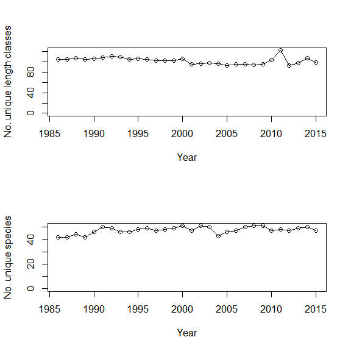

```r
dataSumm = dplyr::summarise(dplyr::group_by(data, Year),
                            uniqLngtClass = length(unique(LngtClass)),
                            uniqSpec = length(unique(SpecCode)))
par(mfrow=c(2,1)) #7,1))

plot(dataSumm$Year, dataSumm$uniqLngtClass, xlab="Year",
     ylab="No. unique length classes", type="o",
     ylim=c(0, max(dataSumm$uniqLngtClass)))
plot(dataSumm$Year, dataSumm$uniqSpec, xlab="Year",
     ylab="No. unique species", type="o", ylim=c(0, max(dataSumm$uniqSpec)))
```

As for the original full data set, there do not look to be any serious issue with this (no drastic changes in, for example, species identification through time).

The remaining `eightMethods.count()` and plotting code from MEPS_IBTS_2.html is not repeated here since it takes a few hours to run, and our focus is on repeating the MLEbins method.

## Analyses of IBTS data using the MLEbins method

This section analyses the IBTS data using the MLEbins method, using the essential calculations from MEPS_IBTS_MLEbins.html.

### Determining which rows are 0.5 cm bins

`LngtClass` for all species is the minimum value of a 1-cm-width bin, except for herring (*Clupea harengus*) and sprat (*Sprattus sprattus*) for which lengths are rounded down to 0.5 cm values (so the bins are 0.5-cm wide). The `SpecCode` values for these are:

```r
herringCode = dplyr::filter(specCodeNames, species == "Clupea harengus")$speccode
herringCode
```

```
#> [1] 126417
```

```r
spratCode = dplyr::filter(specCodeNames, species == "Sprattus sprattus")$speccode
spratCode
```

```
#> [1] 126425
```

```r
specCode05 = c(herringCode, spratCode)      # species codes with 0.5cm length bins
```

Verified earlier that only these two species have 0.5 cm values for `LngtClass`.

### Append the max of the bin breaks for each row

So `LngtClass` is the minimum of each length bin. Need to work out the maximum of each length bin `LengthMax`, and then use the species-specific length-weight relationships to give the min (`wmin`) and max (`wmax`) of each body-mass bin. So create `dataBin` table dataframe that has `LengthMax`, `wmin` and `wmax` as extra columns for each row:

```r
dataBin = dplyr::mutate(data,
                        LngtMax = LngtClass + 1)
aa = which(dataBin$SpecCode %in% specCode05)           # row numbers for herring, sprat
dataBin[aa, "LngtMax"] = dataBin[aa, "LngtMax"] - 0.5  # subtract 0.5 cm to
                                                       # give 0.5-cm wide bins
unique(dataBin$LngtMax - dataBin$LngtClass)            # correctly just has 0.5 and 1
```

```
#> [1] 1
```

```r
unique( dplyr::filter(dataBin, LngtMax - LngtClass == 0.5)$SpecCode)  # just herring,sprat
```

```
#> integer(0)
```

```r
dataBin = dplyr::mutate(dataBin, wmax = LWa * LngtMax^LWb)  # calculate max body mass
                                                            # for each bin (min
                                                            # is currently bodyMass)
dataBin = dplyr::rename(dataBin, LngtMin = LngtClass)       # For consistency
dataBin = dplyr::rename(dataBin, wmin = bodyMass)

dataBin = dataBin[ , c("Year", "SpecCode", "LngtMin", "LngtMax",
                       "LWa", "LWb", "wmin", "wmax", "Number")]     # Reorder columns

range(dplyr::mutate(dataBin,
                    wminCheck = LWa * LngtMin^LWb)$wminCheck - dataBin$wmin)
```

```
#> [1] -2.273737e-13  2.273737e-13
```

```r
                                              # Verifying that wmin is correct
                                              # (was calculated independently)
length(unique(dataBin$SpecCode))
```

```
#> [1] 86
```

No need to re-plot the body-mass bins for each species, since they won’t have changed from the MEPS paper (there will just be no bins below 100 g, and so some species will be omitted).

### Likelihood calculations using MLEbins method

Now use the MLEbins method to fit each year of data in turn.

```r
fullYears = sort(unique(dataBin$Year))
# Do a loop for each year, saving all the results in MLEbins.nSeaFung.new
for(iii in 1:length(fullYears))
  {
    dataBinForLike = dplyr::filter(dataBin,
                                   Year == fullYears[iii])
    dataBinForLike = dplyr::select(dataBinForLike,
                                   SpecCode,
                                   wmin,
                                   wmax,
                                   Number)
    n = sum(dataBinForLike$Number)
    xmin = min(dataBinForLike$wmin)
    xmax = max(dataBinForLike$wmax)

    MLEbins.nSeaFung.oneyear.new  = calcLike(negLL.fn = negLL.PLB.bins.species,
                                             p = -1.9,
                                             suppress.warnings = TRUE,
                                             dataBinForLike = dataBinForLike,
                                             n = n,
                                             xmin = xmin,
                                             xmax = xmax)

    if(iii == 1)
    {
      MLEbins.nSeaFung.new = data.frame(Year = fullYears[iii],
                                        xmin=xmin,
                                        xmax=xmax,
                                        n=n,
                                        b=MLEbins.nSeaFung.oneyear.new$MLE,
                                        confMin=MLEbins.nSeaFung.oneyear.new$conf[1],
                                        confMax=MLEbins.nSeaFung.oneyear.new$conf[2])
    } else {
      MLEbins.nSeaFung.new = rbind(MLEbins.nSeaFung.new,
                                   c(fullYears[iii],
                                     xmin,
                                     xmax,
                                     n,
                                     MLEbins.nSeaFung.oneyear.new$MLE,
                                     MLEbins.nSeaFung.oneyear.new$conf[1],
                                     MLEbins.nSeaFung.oneyear.new$conf[2]))
   }
}

# Need the standard error for weighted linear regression,
#  see eightMethods.count() for details:
MLEbins.nSeaFung.new = dplyr::tbl_df(MLEbins.nSeaFung.new)
MLEbins.nSeaFung.new = dplyr::mutate(MLEbins.nSeaFung.new,
                                     stdErr = (abs(confMin-b) +
                                               abs(confMax-b))/(2*1.96) )
MLEbins.nSeaFung.new
```

```
#> # A tibble: 30 × 8
#>     Year  xmin   xmax     n     b confMin confMax stdErr
#>    <dbl> <dbl>  <dbl> <dbl> <dbl>   <dbl>   <dbl>  <dbl>
#>  1  1986  101. 28723.  917. -2.34   -2.43   -2.26 0.0449
#>  2  1987  100  25974.  849. -2.48   -2.58   -2.38 0.0510
#>  3  1988  102. 29440.  983. -2.83   -2.95   -2.72 0.0584
#>  4  1989  102. 35211. 1058. -2.69   -2.79   -2.59 0.0520
#>  5  1990  102. 34811.  830. -2.66   -2.77   -2.55 0.0574
#>  6  1991  100  26413. 1076. -2.82   -2.93   -2.72 0.0556
#>  7  1992  100  25317. 1102. -2.82   -2.93   -2.71 0.0546
#>  8  1993  100. 29440. 1122. -2.47   -2.56   -2.38 0.0441
#>  9  1994  102. 22201.  973. -2.97   -3.10   -2.85 0.0633
#> 10  1995  102. 31819.  937. -2.67   -2.78   -2.57 0.0546
#> # … with 20 more rows
```

Now to plot the results and obtain the regression fit (uncomment the commented lines to save an explicit file):

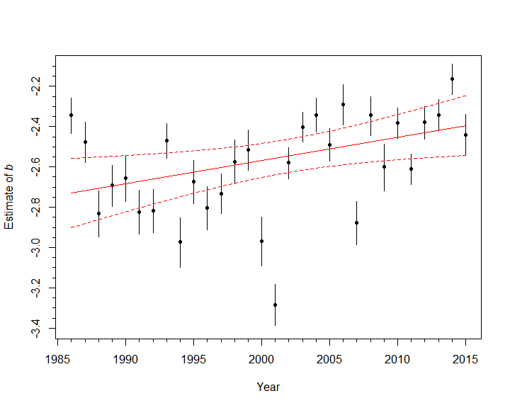

```r
# postscript("../IBTS-min-100/trends100.eps",
#           height = 6, width = 7.5, horizontal = FALSE, paper = "special")
res = timeSerPlot(MLEbins.nSeaFung.new,
                  legName = "(a) MLEbins",
                  yLim = c(-3.4, -2.1),
                  xLab = "Year",
                  method = "",
                  legPos = "bottomleft",
                  weightReg = TRUE,
                  xTicksSmallInc = 1,
                  yTicksSmallInc = 0.05)
```

```r
# dev.off()
```

The statistics for the regression fit (like those in Table S.1) are:

```r
trendResultsMLEbinsNew = dplyr::tbl_df(res)
knitr::kable(dplyr::select(trendResultsMLEbinsNew, Method, Low, Trend, High, p, Rsquared),
             digits=c(NA, 4, 4, 4, 2, 2))
```

| Method | Low | Trend | High | p | Rsquared |
| --- | --- | --- | --- | --- | --- |
|  | 0.0021 | 0.0115 | 0.021 | 0.02 | 0.18 |

For an equivalent to Table S.2 (results for each year for the MLEbins method), need the constant *C* for each year, so calculate it here:

```r
MLEbins.res = MLEbins.nSeaFung.new
MLEbins.res = dplyr::mutate(MLEbins.res,
                            C = (b != -1 ) * (b+1) / ( xmax^(b+1) - xmin^(b+1) ) +
                                (b == -1) * 1 / ( log(xmax) - log(xmin) )
                           )
MLEbins.res = dplyr::select(MLEbins.res, -stdErr)
knitr::kable(dplyr::select(MLEbins.res, Year, xmin, xmax, n, confMin, b,
                           confMax, C),
             digits=c(0, rep(2, 7)))
```

| Year | xmin | xmax | n | confMin | b | confMax | C |
| --- | --- | --- | --- | --- | --- | --- | --- |
| 1986 | 101.35 | 28722.51 | 916.52 | -2.43 | -2.34 | -2.26 | 664.97 |
| 1987 | 100.00 | 25974.17 | 849.17 | -2.58 | -2.48 | -2.38 | 1316.49 |
| 1988 | 101.61 | 29439.75 | 982.90 | -2.95 | -2.83 | -2.72 | 8642.27 |
| 1989 | 101.61 | 35210.99 | 1058.09 | -2.79 | -2.69 | -2.59 | 4175.41 |
| 1990 | 101.61 | 34811.19 | 830.41 | -2.77 | -2.66 | -2.55 | 3509.26 |
| 1991 | 100.00 | 26412.52 | 1076.15 | -2.93 | -2.82 | -2.72 | 8047.32 |
| 1992 | 100.00 | 25316.66 | 1101.53 | -2.93 | -2.82 | -2.71 | 7848.38 |
| 1993 | 100.00 | 29439.75 | 1121.89 | -2.56 | -2.47 | -2.38 | 1270.45 |
| 1994 | 101.61 | 22200.90 | 972.95 | -3.10 | -2.97 | -2.85 | 17969.56 |
| 1995 | 101.61 | 31818.64 | 936.68 | -2.78 | -2.67 | -2.57 | 3805.70 |
| 1996 | 101.61 | 36462.12 | 1117.99 | -2.91 | -2.80 | -2.70 | 7503.47 |
| 1997 | 100.00 | 19360.99 | 1188.82 | -2.83 | -2.73 | -2.63 | 5028.09 |
| 1998 | 101.61 | 22801.53 | 820.29 | -2.68 | -2.57 | -2.47 | 2258.31 |
| 1999 | 101.61 | 36462.12 | 892.03 | -2.62 | -2.51 | -2.42 | 1648.97 |
| 2000 | 101.35 | 22801.53 | 988.64 | -3.09 | -2.97 | -2.85 | 17382.96 |
| 2001 | 101.61 | 18824.87 | 1927.54 | -3.39 | -3.28 | -3.18 | 87714.71 |
| 2002 | 100.00 | 20464.76 | 1612.89 | -2.66 | -2.58 | -2.50 | 2272.10 |
| 2003 | 100.00 | 21611.31 | 1402.35 | -2.48 | -2.40 | -2.33 | 893.83 |
| 2004 | 101.61 | 30911.23 | 990.74 | -2.43 | -2.34 | -2.26 | 658.50 |
| 2005 | 100.00 | 19360.99 | 1294.30 | -2.57 | -2.49 | -2.41 | 1418.93 |
| 2006 | 100.00 | 21032.63 | 667.38 | -2.39 | -2.29 | -2.19 | 487.54 |
| 2007 | 100.00 | 18299.10 | 1150.19 | -2.99 | -2.88 | -2.77 | 10584.74 |
| 2008 | 100.00 | 28722.51 | 759.07 | -2.44 | -2.34 | -2.25 | 654.72 |
| 2009 | 100.00 | 24036.35 | 732.37 | -2.72 | -2.60 | -2.49 | 2542.18 |
| 2010 | 101.61 | 23293.68 | 1344.75 | -2.46 | -2.38 | -2.31 | 820.76 |
| 2011 | 101.35 | 26723.46 | 1742.68 | -2.69 | -2.61 | -2.54 | 2738.92 |
| 2012 | 100.00 | 14899.37 | 1177.94 | -2.46 | -2.38 | -2.30 | 789.30 |
| 2013 | 100.00 | 25974.17 | 1213.46 | -2.42 | -2.34 | -2.27 | 647.73 |
| 2014 | 100.00 | 30025.12 | 948.17 | -2.24 | -2.16 | -2.09 | 245.86 |
| 2015 | 100.00 | 18362.51 | 792.09 | -2.54 | -2.44 | -2.34 | 1088.61 |

## Recommended plotting approach from the MLEbins method

Recommended plotting approach of results for each year, as in MEPS_IBTS_recommend.html.

First just get what’s needed for the calculations for the recommended plot:

```r
dataRecommend.isd = dplyr::select(dataBin,
                                  Year,
                                  wmin,
                                  wmax,
                                  Number)

data.year.list = list()                # to save results for each year

fullYears = sort(unique(dataBin$Year))
for(i in 1:length(fullYears))
  {
    data.year = dplyr::filter(dataRecommend.isd,
                              Year == fullYears[i])

    data.year = dplyr::arrange(data.year,
                               desc(wmin))
    sumNumber = sum(data.year$Number)

    # Have to do not with dplyr:
    wmin.vec = data.year$wmin
    wmax.vec = data.year$wmax
    num.vec  = data.year$Number

    countGTEwmin = rep(NA, length(num.vec)) # to do a manual count
    lowCount = countGTEwmin
    highCount = countGTEwmin

    for(iii in 1:length(countGTEwmin))
    {
      countGTEwmin[iii]    = sum( (wmin.vec >= wmin.vec[iii]) * num.vec)
      lowCount[iii]  = sum( (wmin.vec >= wmax.vec[iii]) * num.vec)
      highCount[iii] = sum( (wmax.vec >  wmin.vec[iii]) * num.vec)
    }
    data.year = cbind(data.year,
                      "countGTEwmin" = countGTEwmin,
                      "lowCount" = lowCount,
                      "highCount" = highCount)
    data.year = dplyr::tbl_df(data.year)

    data.year.list[[i]] = data.year
}
```

Here is the code to give an animation for the equivalent Figures 7 and S.5-S.34 for the IBTS data (now with minimum body size set to 100 g). For each year (given in top-right corner) the plot shows the individual size distribution and MLEbins fit (red solid curve) with 95% confidence intervals (red dashed curves, may be hard to see). For each bin, the horizontal green line shows the range of body sizes, with value on the y-axis corresponding to the total number of individuals in bins whose minima are $\geq$ the bin’s minimum. For each bin, the vertical span of the grey rectangle shows the possible range of the number of individuals with body mass $\geq$ the body mass of individuals in that bin (horizontal span is the same as for the green lines). The text in (a) gives the year, the MLE for the size-spectrum exponent $b$, and the sample size $n$.

```r
xlim.global = c(min(dataRecommend.isd$wmin),
                max(dataRecommend.isd$wmax))
```

Here is the code to build the movie, but it is commented out since it causes Travis to fail – Travis is the continuous integration service that automatically checks the packages builds every time a change is committed to GitHub, giving the little green symbol `passing` icon on the main page. The trick to showing the movie is to run the code uncommented (you need to install the `gifski` package), right-click on the animation in the html viewer and save it. I’ve done that and so am leaving this code commented, and will just refer to the saved animation file.

````r
# ```
# {r, animation.hook = 'gifski', interval = 1.5, fig.width = 5.36, fig.height = 8}
## fig.width is 0.67 * fig.height (which is 8)
#
#for(i in 1:length(fullYears))
#  {
#  ISD_bin_plot(data.year = data.year.list[[i]],
#              b.MLE = dplyr::filter(MLEbins.res, Year == fullYears[i])$b,
#              b.confMin = dplyr::filter(MLEbins.res, Year ==
#                                                   fullYears[i])$confMin,
#              b.confMax = dplyr::filter(MLEbins.res, Year ==
#                                                   fullYears[i])$confMax,
#              year = fullYears[i],
#              xlim = xlim.global,
#              xmin = dplyr::filter(MLEbins.res, Year ==
#                                                   fullYears[i])$xmin,
#              xmax = dplyr::filter(MLEbins.res, Year ==
#                                                fullYears[i])$xmax,
#              yBig.inc = 500,
#              ySmall.inc = 100,
#              IBTS_MEPS_figs = TRUE)
# }
# ```
````

The resulting animation is

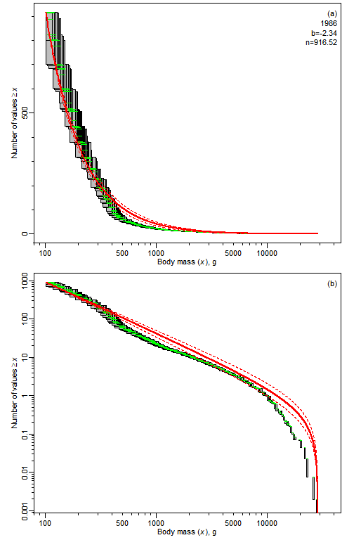

.

To save each year as it’s own figure do this (not it running here; you have to make the `IBTS-min-100` directory first):

```r
for(i in 1:length(fullYears))
  {
  postscript(paste0("../IBTS-min-100/IBTS-ISD", fullYears[i], ".eps"),
           height = 8, width = 5.36,
           horizontal=FALSE, paper="special")

  ISD_bin_plot(data.year = data.year.list[[i]],
               b.MLE = dplyr::filter(MLEbins.res, Year == fullYears[i])$b,
               b.confMin = dplyr::filter(MLEbins.res, Year ==
                                                     fullYears[i])$confMin,
               b.confMax = dplyr::filter(MLEbins.res, Year ==
                                                     fullYears[i])$confMax,
               year = fullYears[i],
               xlim = xlim.global,
               xmin = dplyr::filter(MLEbins.res, Year ==
                                                    fullYears[i])$xmin,
               xmax = dplyr::filter(MLEbins.res, Year ==
                                                 fullYears[i])$xmax,
               yBig.inc = 500,
               ySmall.inc = 100,
               IBTS_MEPS_figs = TRUE)
  dev.off()
}
```

See MEPS_IBTS_recommend.html for inserting all the figures into a LaTeX document using a loop.